# Matplotlib – Basic Python for Econ Students

Author

Kittikun Jitpairod

Modified

September 4, 2024

## Introduction to Matplotlib

Matplotlib is a comprehensive library for creating static, animated, and interactive visualizations in Python. It provides a MATLAB-like interface, especially when used with IPython. Let’s explore some common plot types and how to create them.

First, let’s import the necessary libraries:

**Matplotlib**

```python
import matplotlib.pyplot as plt
import numpy as np
import pandas as pd
```

**Plotly**

```python
import plotly.express as px
import plotly.graph_objects as go
import pandas as pd
import numpy as np
```

## Line Plot

Line plots are great for showing trends over time or any continuous data.

```python
years = np.arange(2010, 2021)
population = [8.5, 8.7, 8.9, 9.1,
            9.3, 9.5, 9.7, 9.9,
            10.1, 10.3, 10.5]

df = pd.DataFrame({'Year': years, 'Population': population})
```

**Matplotlib**

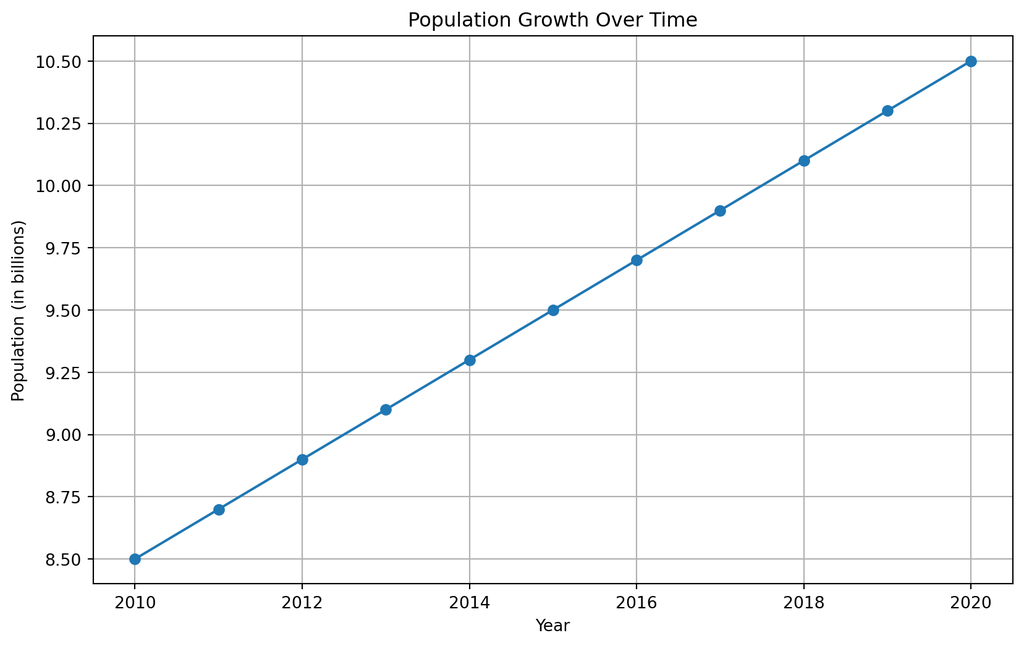

```python
# Create the plot
plt.figure(figsize=(10, 6))
plt.plot(df['Year'], df['Population'], marker='o')

# Customize the layout
plt.title('Population Growth Over Time')
plt.xlabel('Year')
plt.ylabel('Population (in billions)')
plt.grid(True)

# Show the plot
plt.show()
```

**Plotly**

```python
# Create the plot
fig = px.line(df, x='Year', y='Population', markers=True,
              title='Population Growth Over Time',
              labels={'Population': 'Population (in billions)'},
              )

# Customize the layout
fig.update_layout(
    font=dict(size=12),
    height=600,
    width=800
)

# Show the plot
fig.show()
```

[interactive chart not shown]

## Vertical Bar Plot

Bar plots are useful for comparing quantities across different categories.

```python
data = {
    'Country': ['USA', 'China', 'Japan', 'Germany', 'UK'],
    'GDP': [21.43, 14.34, 5.08, 3.86, 2.83]
}

df = pd.DataFrame(data)
```

**Matplotlib**

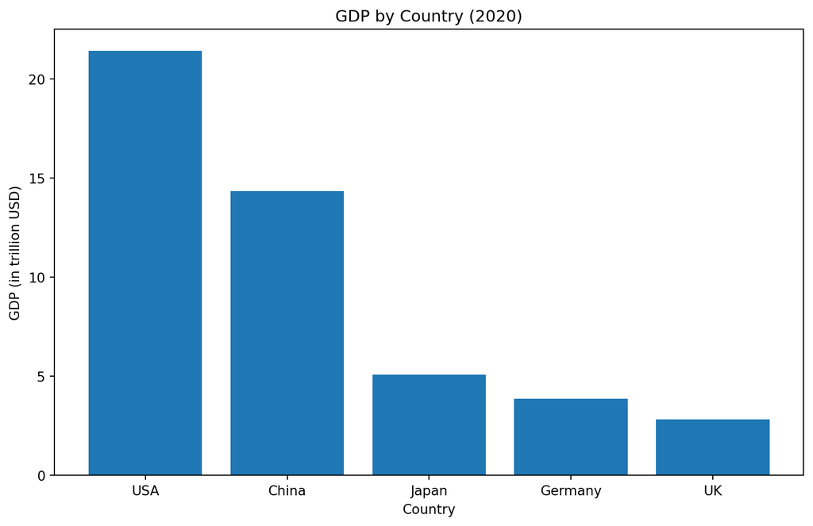

```python
# Create the plot
plt.figure(figsize=(10, 6))
plt.bar(df['Country'], df['GDP'])

# Customize the layout
plt.title('GDP by Country (2020)')
plt.xlabel('Country')
plt.ylabel('GDP (in trillion USD)')

# Show the plot
plt.show()
```

We can use the `ax.bar_label()` method, which is a more straightforward way, to add labels to bar plots.

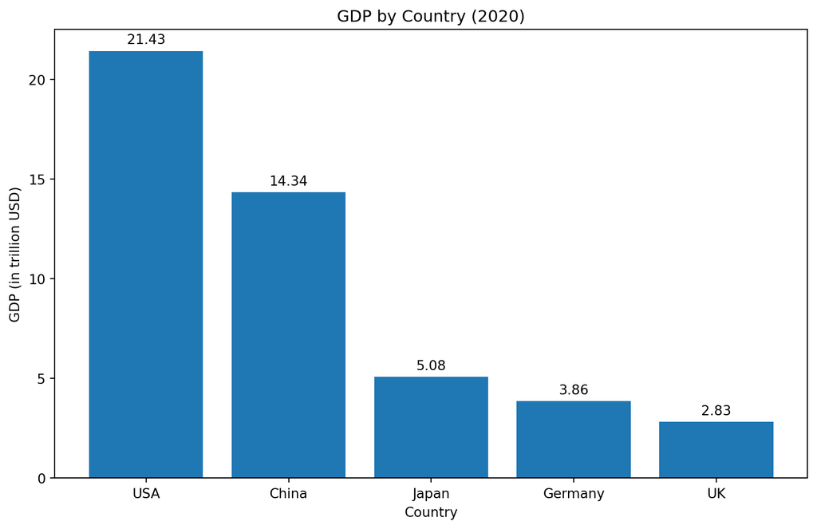

```python
fig, ax = plt.subplots(figsize=(10, 6))
bars = ax.bar(df['Country'], df['GDP'])
ax.set_title('GDP by Country (2020)')
ax.set_xlabel('Country')
ax.set_ylabel('GDP (in trillion USD)')

# Add value labels on the bars
ax.bar_label(bars, fmt='%.2f', padding=3)

plt.show()
```

**Poltly**

```python
# Create the plot
fig = px.bar(df, x='Country', y='GDP',
             title='GDP by Country (2020)',
             labels={'GDP': 'GDP (in trillion USD)'},
             text='GDP',  # This will display the GDP values on the bars
             height=600, width=800)

# Customize the layout
fig.update_traces(texttemplate='%{text:.2f}', textposition='outside')
fig.update_layout(uniformtext_minsize=8, uniformtext_mode='hide')

# Show the plot
fig.show()
```

[interactive chart not shown]

## Horizontal Bar Plot

```python
countries = ['China', 'Japan', 'USA',
            'Germany', 'UK']
gdp = [14.34, 5.08, 21.43, 3.86, 2.83]

df = pd.DataFrame({
    'Country': countries,
    'GDP': gdp,
})
df.sort_values(by = 'GDP', inplace = True)
print(df)
```

```
   Country    GDP
4       UK   2.83
3  Germany   3.86
1    Japan   5.08
0    China  14.34
2      USA  21.43
```

**Matplotlib**

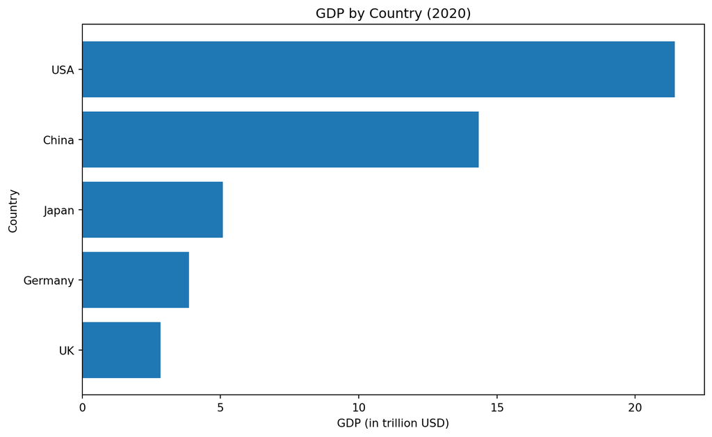

```python
# Create the plot
plt.figure(figsize=(10, 6))

# Customize the layout
plt.barh(df['Country'], df['GDP'])
plt.title('GDP by Country (2020)')
plt.xlabel('GDP (in trillion USD)')
plt.ylabel('Country')

# Show the plot
plt.show()
```

We can use the `ax.bar_label()` method, which is a more straightforward way, to add labels to bar plots.

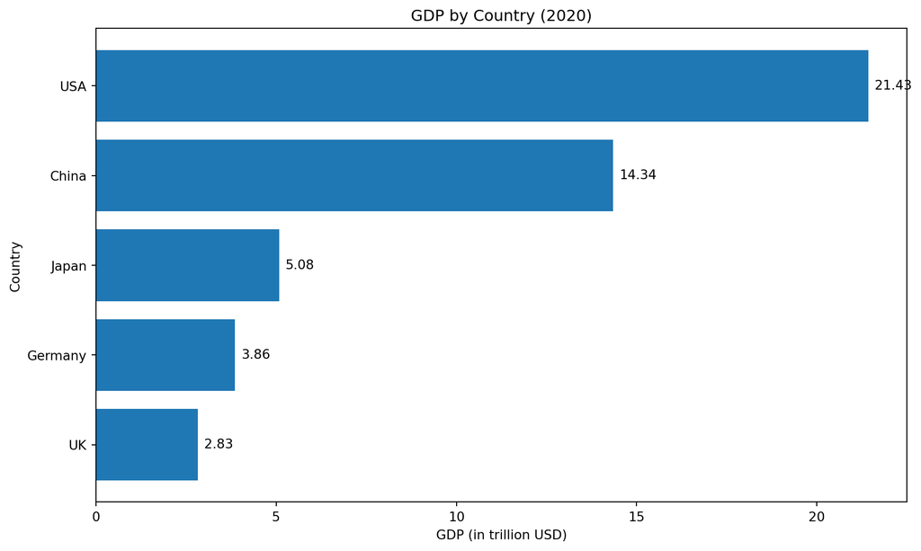

```python
# Create the plot
fig, ax = plt.subplots(figsize=(10, 6))
bars = ax.barh(df['Country'], df['GDP'])

# Add value labels on the bars
ax.bar_label(bars, fmt='%.2f', padding=5)

# Customize the plot
ax.set_title('GDP by Country (2020)')
ax.set_xlabel('GDP (in trillion USD)')
ax.set_ylabel('Country')

# Adjust layout to prevent clipping of labels
plt.tight_layout()

# Show the plot
plt.show()
```

**Plotly**

```python
# Create the plot
fig = px.bar(df,
             x='GDP',
             y='Country',
             orientation='h',
             title='GDP by Country (2020)',
             labels={'GDP': 'GDP (in trillion USD)'},
             text='GDP',
             height=500,
             width=800)

# Customize the layout
fig.update_traces(texttemplate='%{text:.2f}', textposition='outside')
fig.update_layout(yaxis={'categoryorder':'total ascending'})

# Show the plot
fig.show()
```

[interactive chart not shown]

## Scatter Plot

Scatter plots are excellent for showing the relationship between two variables.

```python
height = np.random.normal(170, 10, 100)
weight = np.random.normal(70, 10, 100)

df = pd.DataFrame({
    'Height (cm)': height,
    'Weight (kg)': weight
})
```

**Matplotlib**

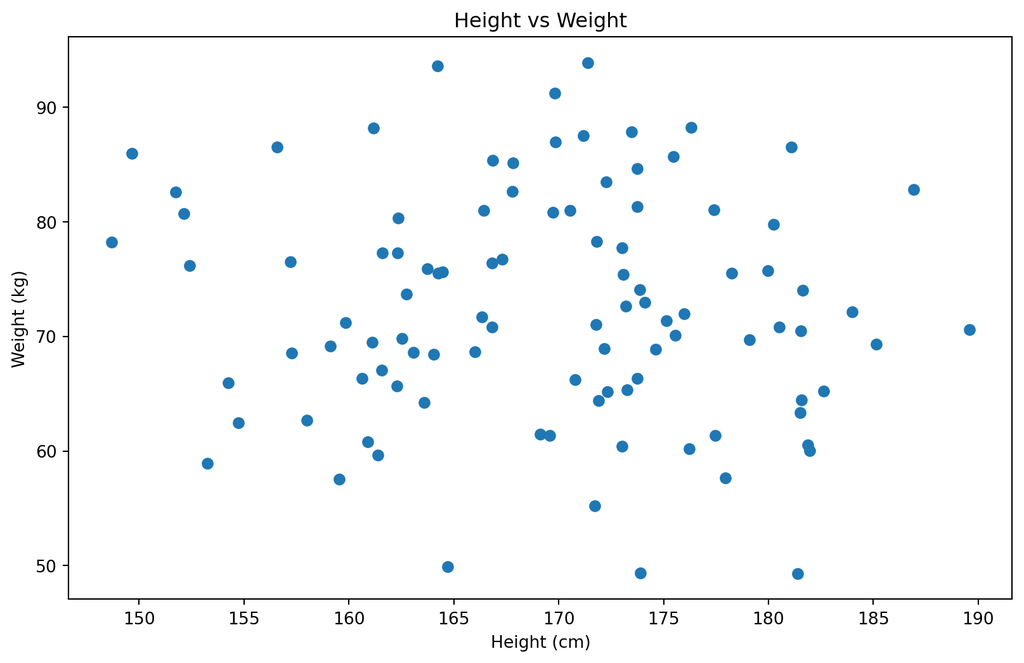

```python
# Create the plot
plt.figure(figsize=(10, 6))
plt.scatter(height, weight)

# Customize the layout
plt.title('Height vs Weight')
plt.xlabel('Height (cm)')
plt.ylabel('Weight (kg)')

# Show the plot
plt.show()
```

**Plotly**

```python
# Create the plot
fig = px.scatter(df, x='Height (cm)', y='Weight (kg)',
                 title='Height vs Weight',
                 labels={'Height (cm)': 'Height (cm)', 'Weight (kg)': 'Weight (kg)'},
                 height=600, width=800)

# Customize the layout
fig.update_traces(marker=dict(size=8))
fig.update_layout(
    title_font_size=20,
    xaxis_title_font_size=14,
    yaxis_title_font_size=14
)

# Show the plot
fig.show()
```

[interactive chart not shown]

## Histogram

Histograms show the distribution of a dataset.

```python
data = np.random.normal(0, 1, 1000)
df = pd.DataFrame({'Value': data})
```

**Matplotlib**

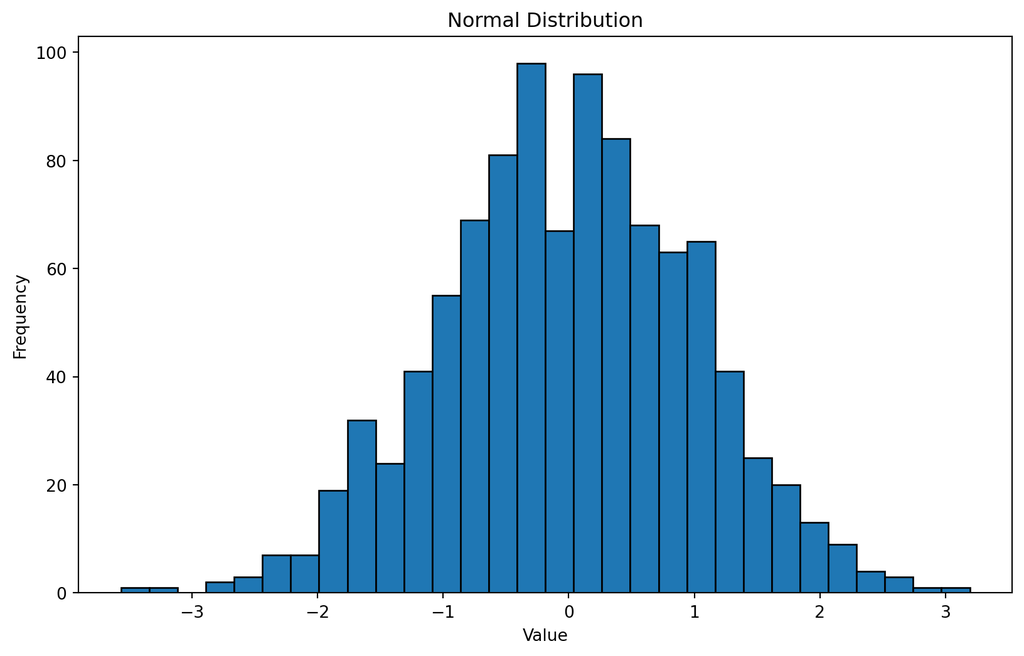

```python
# Create the plot
plt.figure(figsize=(10, 6))
plt.hist(data, bins=30, edgecolor='black')

# Customize the layout
plt.title('Normal Distribution')
plt.xlabel('Value')
plt.ylabel('Frequency')

# Show the plot
plt.show()
```

**Plotly**

```python
# Create the plot
fig = px.histogram(df, x='Value',
                   nbins=30,
                   title='Normal Distribution',
                   labels={'Value': 'Value', 'count': 'Frequency'},
                   height=600, width=800)

# Customize the layout
fig.update_traces(marker_line_color="black", marker_line_width=1)
fig.update_layout(
    title_font_size=20,
    xaxis_title_font_size=14,
    yaxis_title_font_size=14
)

# Show the plot
fig.show()
```

[interactive chart not shown]

## Pie Chart

Pie charts are used to show proportions of a whole.

```python
categories = ['Housing', 'Food',
    'Transport', 'Entertainment',
    'Savings']
expenses = [35, 25, 15, 10, 15]

df = pd.DataFrame({
    'Category': categories,
    'Expense': expenses
})
```

**Matplotlib**

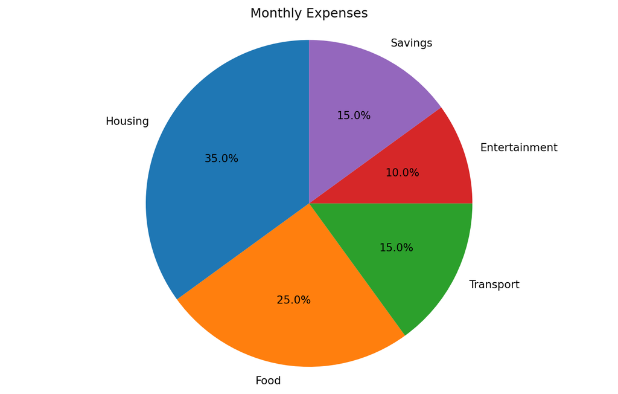

```python
# Create the plot
plt.figure(figsize=(10, 6))
plt.pie(expenses, labels=categories, autopct='%1.1f%%', startangle=90)

# Customize the layout
plt.title('Monthly Expenses')
plt.axis('equal')  # Equal aspect ratio

# Show the plot
plt.show()
```

**Plotly**

```python
# Create the plot
fig = px.pie(df,
             values='Expense',
             names='Category',
             title='Monthly Expenses',
             height=600,
             width=800)

# Customize the layout
fig.update_traces(textposition='inside', textinfo='percent+label')
fig.update_layout(
    title_font_size=20,
    legend_title_font_size=14,
    uniformtext_minsize=12,
    uniformtext_mode='hide'
)

# Show the plot
fig.show()
```

[interactive chart not shown]

## Subplots

Subplots allow you to combine multiple plots in one figure.

```python
x = np.linspace(0, 10, 100)
y1 = np.sin(x)
y2 = np.cos(x)
```

**Matplotlib**

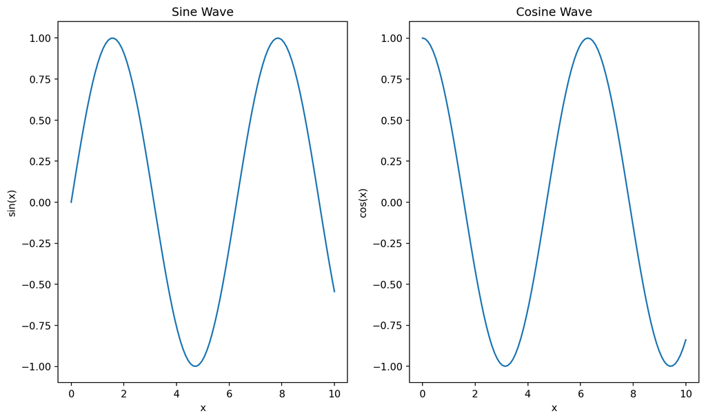

```python
fig, axs = plt.subplots(1,2,figsize=(10,6))

axs[0].plot(x, y1)
axs[0].set_title('Sine Wave')
axs[0].set_xlabel('x')
axs[0].set_ylabel('sin(x)')

axs[1].plot(x, y2)
axs[1].set_title('Cosine Wave')
axs[1].set_xlabel('x')
axs[1].set_ylabel('cos(x)')

plt.tight_layout()
plt.show()
```

**Plotly**

```python
from plotly.subplots import make_subplots

# Create subplots
fig = make_subplots(rows=1, cols=2, subplot_titles=("Sine Wave", "Cosine Wave"))

# Add traces for sine wave
fig.add_trace(
    go.Scatter(x=x, y=y1, name="sin(x)"),
    row=1, col=1
)

# Add traces for cosine wave
fig.add_trace(
    go.Scatter(x=x, y=y2, name="cos(x)"),
    row=1, col=2
)

# Update layout
fig.update_layout(
    height=600, width=1000,
    title_text="Sine and Cosine Waves",
    showlegend=False
)

# Update x and y axis labels
fig.update_xaxes(title_text="x", row=1, col=1)
fig.update_xaxes(title_text="x", row=1, col=2)
fig.update_yaxes(title_text="sin(x)", row=1, col=1)
fig.update_yaxes(title_text="cos(x)", row=1, col=2)

# Show the plot
fig.show()
```

[interactive chart not shown]

## Box Plot

Box plots are useful for showing the distribution of data and identifying outliers:

```python
df = pd.DataFrame({
    'value_a': np.random.randn(100),
    'value_b': np.random.randn(100),
})
```

**Matplotlib**

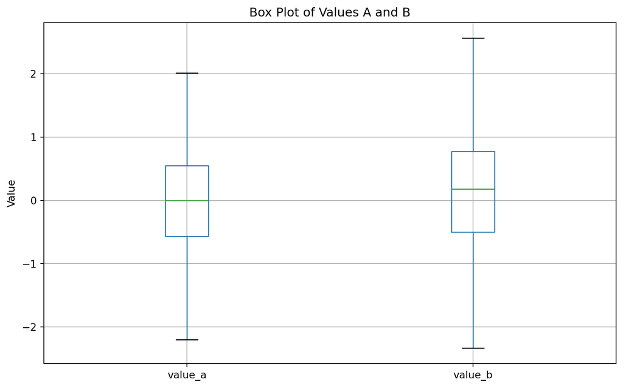

```python
df.boxplot(column=['value_a', 'value_b'], figsize=(10, 6))

plt.title('Box Plot of Values A and B')
plt.ylabel('Value')
plt.grid(True)
plt.show()
```

**Plotly**

```python
# Melt the DataFrame to long format
df_melted = df.melt(var_name='Variable', value_name='Value')

# Create the box plot
fig = px.box(df_melted, x='Variable', y='Value',
             title='Box Plot of Values A and B',
             labels={'Variable': 'Variable', 'Value': 'Value'},
             height=600, width=800)

# Customize the layout
fig.update_layout(
    title_font_size=20,
    xaxis_title_font_size=14,
    yaxis_title_font_size=14,
    showlegend=False
)

# Add grid lines
fig.update_yaxes(showgrid=True, gridwidth=1, gridcolor='LightGrey')

# Show the plot
fig.show()
```

[interactive chart not shown]

## Customizing Plots

Matplotlib offers many customization options. Here’s an example with a customized line plot:

```python
x = np.linspace(0, 10, 100)
y1 = np.exp(-x/10)*np.sin(x)
y2 = x/10
```

**Matplotlib**

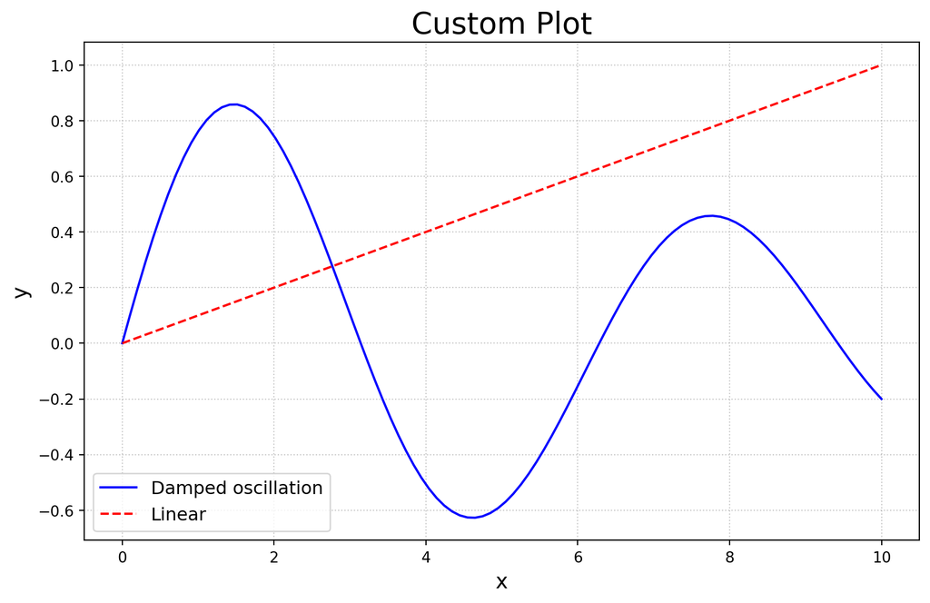

```python
# Create the figure
plt.figure(figsize=(10, 6))

# Add traces
plt.plot(x, y1, 'b-', label='Damped oscillation')
plt.plot(x, y2, 'r--', label='Linear')

# Update layout
plt.title('Custom Plot', fontsize=20)
plt.xlabel('x', fontsize=14)
plt.ylabel('y', fontsize=14)
plt.legend(fontsize=12)

# Add grid
plt.grid(True, linestyle=':', alpha=0.7)

# Show the plot
plt.show()
```

**Poltly**

```python
# Create the figure
fig = go.Figure()

# Add traces
fig.add_trace(go.Scatter(x=x, y=y1, mode='lines', name='Damped oscillation',
                         line=dict(color='blue', width=2)))
fig.add_trace(go.Scatter(x=x, y=y2, mode='lines', name='Linear',
                         line=dict(color='red', width=2, dash='dash')))

# Update layout
fig.update_layout(
    title=dict(text='Custom Plot', font=dict(size=20)),
    xaxis=dict(title='x', titlefont=dict(size=14)),
    yaxis=dict(title='y', titlefont=dict(size=14)),
    legend=dict(font=dict(size=12)),
    height=600,
    width=1000,
    hovermode='x unified',
)

# Add grid
fig.update_xaxes(showgrid=True, gridwidth=1, gridcolor='rgba(0,0,0,0.1)')
fig.update_yaxes(showgrid=True, gridwidth=1, gridcolor='rgba(0,0,0,0.1)')

# Show the plot
fig.show()
```

[interactive chart not shown]